# Lab One: Visualization and Data Preprocessing

### Ryan Bass, Brett Benefield, Cho Kim, Nicole Wittlin

# Resubmission Summary

## Simple Statistics

- Write up of Simple Statistics about College Enrollment Data
- Write up of Simple Statistics about Personnel Data

## Explore Attributes and Class

- Individual scatter plots of the % students who enrolled in college versus: % licensed teachers, average number of teachers per school, number of National Board Certified Staff, the % one year teacher turnover, % of teachers with 11+ years of experience, and % of teachers with 0-3 years of experience, and % one year turnover of teachers.
- Individual box plots of the quartiles of % students who enrolled in college versus: % licensed teachers, average number of teachers per school, number of National Board Certified Staff, the % one year teacher turnover, % of teachers with 11+ years of experience, % of teachers with 0-3 years of experience, and % one year turnover of teachers.

## New Features

- Added information about new features we could consider

# Business Understanding

The team selected data from the Belk Endowment Educational Attainment Data for North Carolina Public Schools, which contains the North Carolina Public Schools Report Card as well as the Statistical Profiles Databases. This data was compiled by Dr. Jake Drew from original sources provided by the Public Schools of North Carolina (http://ncpublicschools.org), and the compilation, research, and analysis of the educational attainment data was funded by the John M. Belk Endowment (JMBE).

JMBE’s mission is focused on postsecondary education in North Carolina to help underrepresented students access and complete postsecondary education and be better prepared for entering the workforce. The educational attainment data set contains comprehensive statistics, demographics, and achievement metrics about North Carolina public, charter, and alternative elementary, middle, and high schools. This wealth of data is the foundation for research to help JMBE understand trends and improve postsecondary pathways in the state.

Our team has selected a subset from the larger educational attainment data to explore the relationship between enrollment in postsecondary education within 16 months of high school graduation and teacher metrics related to teacher education, licensing, and certification, in addition to years of experience. This is important to help identify both positive and negative factors influencing students’ enrollment decisions and understand how educators can impact the pipeline to higher education.

Our efforts will include a model that will attempt to identify key attributes that will increase or decrease the percentage of students enrolled in a postsecondary education. The effectiveness of the model will be measured by how accurately our model performs against a test set of data. Our goal is to build a model that can predit the percentage of students who enrolled in postsecondary education within 25% of the real value.

# Data Meaning Type

We used the [College Enrollment data set](https://github.com/jakemdrew/EducationDataNC/blob/master/2017/Raw%20Datasets/college-enrollment.csv) and the [Personnel data set](https://github.com/jakemdrew/EducationDataNC/blob/master/2017/Raw%20Datasets/personnel.csv) available in the EducationDataNC repository published by Dr. Drew.

#### College Enrollment data set

The college enrollment data set we examined has 12,827 rows of data, with 13 attributes. The data set contains counts and percentages of postsecondary enrollment action as defined by the US Department of Education C160 EDEN (Education Data Exchange Network) for students who graduated in 2015. The data has subgroups of counts and percentages by school, district, and the state. A status of ENROLL means the count or percentage enrolled in an institution of higher education (IHE) within 16 months of receiving a regular high school diploma, and NOENROLL means the count or percentage of students who did not enroll in an IHE within 16 months of receiving a high school diploma.

The description of the attributes below can be found in the [data dictionary](http://www.ncpublicschools.org/docs/src/researchers/data-dictionary.pdf) published by the NC Public Schools.

[output not shown]

#### College Enrollment Table Summary

The schcount is the count of students within a school that enrolled or did not enroll in an institute of higher education within 16 months of receiving their high school diploma. The values range from 5 to 423 in the data set.

The leacount is the count of students within a LEA or Charter by subgroup and status. The values range from 5 to 5844 in the data set.

The seacount is the count of students within the state by subgroup and status. The values range from 49 to 51,362.

The "...percent_enrolled" attributes are on a scale from 0 to 100 and represent the percentage of enrolled students among total students within the school, LEA/Charter, or the state.

#### Personnel data set

As part of the data preparation process, we removed data from the personnel set related to grade schools and middle schools (i.e. category codes E, M, and I) because we are focused on the segment of the pipeline that leads from high school to enrollment in postsecondary education. We also removed 26 attributes that contained 84.7% or more missing values. Out of the 26 attributes, 15 attributes contained no values. All 15 attributes were data about highly qualified teachers.

| Column Name | Description | Type | % missing (in %) |
| --- | --- | --- | --- |
| Year | School Year | Nominal | 0 |
| Unit_code | Code to identify School/LEA/State | Nominal | 0 |
| School_Name | School Name | Nominal | 15.4 |
| Lea_Name | LEA Name | Nominal | .2 |
| State_Name | State Name | Nominal | 0 |
| Category_cd | Category code E School has elementary schools grades (PK-5) M School has middle school grades (6-8) H School has high school grades (9-13) I School has elementary and middle school grades T School has… | Nominal | .1 |
| St_Prin_advance_dgr_pct | Percent of principals with advanced degrees at state level | Ordinal | .1 |
| St_1yr_prin_trnovr_pct | One year principal turnover rate at state level | Ordinal | .1 |
| St_Prin_male_pct | Percent of male principals at state level | Ordinal | .1 |
| St_prin_female_pct | Percent of female principals at state level | Ordinal | .1 |
| St_Prin_black_pct | Percent of black principals at state level | Ordinal | .1 |
| St_Prin_white_pct | Percent of white principals at state level | Ordinal | .1 |
| Prin_other_pct | Percent of principals of other races including Indian, Asian, Hispanic and Pacific-islander at LEA level | Ordinal | 84.7 |
| St_Prin_other_pct | Percent of principals of other races including Indian, Asian, Hispanic and Pacific-islander at state level | Ordinal | .1 |
| Flicensed_teach_pct | Percent of teachers that meet NC fully licensed definition at school level | Ordinal | 15.5 |
| Lea_flicensed_teach_pct | Average Percent of Teachers that meet NC fully licensed definition at LEA level | Ordinal | 6.7 |
| St_flicensed_teach_pct | Average Percent of Teachers that meet NC fully licensed definition at state level | Ordinal | .1 |
| Class_teach_num | Average number of classroom teachers at School Level | Continuous | 15.5 |
| Lea_class_teach_num | Average number of classroom teachers at LEA Level | Continuous | 6.7 |
| St_class_teach_num | Average number of classroom teachers at State Level | Continuous | .1 |
| nbpts_num | Number of National Board Certified staff at LEA level | Continuous | 20.9 |
| Lea_nbpts_num | Average number of National Board Certified staff at LEA level | Continuous | 6.7 |
| St_nbpts_num | Average number of National Board Certified staff at state level | Continuous | .1 |
| advance_dgr_pct | Percent of teachers with masters or higher degree at school level | Ordinal | 20.9 |
| Lea_advance_dgr_pct | Average percent of teachers with masters or higher degree at LEA level | Ordinal | 209 |
| St_advance_dgr_pct | Average percent of teachers with masters or higher degree at state level | Ordinal | .1 |
| _1yr_tchr_trnovr_pct | One Year Teacher turnover percentage at school level | Ordinal | 21.6 |
| Lea_1yr_tchr_trnovr_pct | One Year Teacher turnover percentage at LEA level | Ordinal | 209 |
| St_1yr_tchr_trnovr_pct | One Year Teacher turnover percentage at state level | Ordinal | .1 |
| Lateral_teach_pct | lateral entry teacher percentage at school level | Ordinal | 45.8 |
| Lea_lateral_teach_pct | Average lateral entry teacher percentage at LEA level | Ordinal | 6.7 |
| St_lateral_teach_pct | Average lateral entry teacher percentage at state level | Ordinal | .1 |
| Total_class_teacher_num | Number of classroom teachers | Continuous | 0 |
| Total_nbpts_num | Number of National Board Certified teachers | Continuous | 0 |

# Data Quality

In the college enrollment data set, we first removed all the records that summarized data for charter schools, the district, and state level. School level data includes enrollment percentages for both district and state level statistics already.

Next, we examined the data set based on two key attributes: ENROLLED and ALL, which, when combined, created a subset of all the students that enrolled in postsecondary education. We limited this initial analysis to only this highest categorization of all students (rather than drilling down into gender, ethnicity, socio-economic status, etc.).

```python
%matplotlib inline
import seaborn as sns
cmap = sns.diverging_palette(220, 10, as_cmap=True) # one of the many color mappings

import pandas as pd
import numpy as np
import matplotlib.pyplot as plt
from pandas.plotting import scatter_matrix
from IPython.display import HTML, display
```

```python
verboseStatus = False
```

```python
# Brett's directory
# Desktop
#%cd "C:\Sandbox\SMU\dataMining\ChoRepo\EducationDataNC\2017\Raw Datasets"
# Laptop
# %cd "C:\sandbox\SMU\dataMining\choNotebook\EducationDataNC\2017\Raw Datasets"

# Ryan's directory
#%cd "C:\Users\Clovis\Documents\7331DataMining\EducationDataNC\2017\Raw Datasets"

# Cho's directory. Either uncomment the cd statement above or make your own cd.
%cd "/Users/chostone/Documents/Data Mining/7331DataMining/EducationDataNC/2017/Raw Datasets"

# NW directorY
#%cd "C:\Users\Nicole Wittlin\Documents\7331DataMining\EducationDataNC\2017\Raw Datasets"
dfCollege = pd.read_csv("college-enrollment.csv")
dfTeachers = pd.read_csv("personnel.csv")

print('********* Initial Values Before Cleaning *******************')
dfCollege.info(verbose = verboseStatus)
```

```
/Users/chostone/Documents/Data Mining/7331DataMining/EducationDataNC/2017/Raw Datasets
********* Initial Values Before Cleaning *******************
<class 'pandas.core.frame.DataFrame'>
RangeIndex: 12827 entries, 0 to 12826
Columns: 13 entries, graduation_year to sea_percent_enrolled
dtypes: float64(6), int64(1), object(6)
memory usage: 1.3+ MB
```

Code adapted from Dr. Jake Drew's python notebook

- https://github.com/jakemdrew/EducationDataNC/tree/master/2017/School%20Datasets/Source%20Code

Despite having access to the ML dataset for all public schools, we opted to apply the code used to create the ML dataset to create a clean set of data limited to the college enrollment information and personnel files. We reduced the data down to only public schools (no charter schools). Duplicate information on district and state percentage information was removed as it was unnecessary. For the personnel data we limited the information to teachers for high school grades. Once the unnecessary columns and rows were removed, we merged the two datasets on unit_code (school id). A descrepancy was found in the personnel data which included unit_codes which were not in the college enrollment file. Since we had no information on these additional schools, they were excluded from our data.

```python
# Global declaration to limit float values to 2 significant figures
pd.options.display.float_format = '{:.2f}'.format
```

## Clean Teacher Dataset

```python
# For this study we are interested in only looking at public schools
# Remove district and state rows as this is duplicate information
pattern = r'\D'
filterResult = dfTeachers['unit_code'].str.contains(pattern)
dfTeachers = dfTeachers[~filterResult]

#Review dataset contents after drops
print('*********After: Removing rows with charter/district/state codes.*******************')
dfTeachers.info(verbose = verboseStatus)
print("Rows deleted: {}".format(filterResult.sum()))
```

```
*********After: Removing rows with charter/district/state codes.*******************
<class 'pandas.core.frame.DataFrame'>
Int64Index: 2450 entries, 2 to 3084
Columns: 73 entries, year to st_prin_other_pct
dtypes: float64(65), int64(3), object(5)
memory usage: 1.4+ MB
Rows deleted: 646
```

```python
# Remove any teachers that don't teach high school
pattern = r'E|M|I'
filterResult = dfTeachers['category_cd'].str.contains(pattern, na = False)
dfTeachersHS = dfTeachers[~filterResult]

#Review dataset contents after drops
print('*********After: Removing rows for elementary and middle school teachers.*******************')
dfTeachersHS.info(verbose = verboseStatus)
print("Rows deleted: {}".format(filterResult.sum()))
```

```
*********After: Removing rows for elementary and middle school teachers.*******************
<class 'pandas.core.frame.DataFrame'>
Int64Index: 600 entries, 2 to 3083
Columns: 73 entries, year to st_prin_other_pct
dtypes: float64(65), int64(3), object(5)
memory usage: 346.9+ KB
Rows deleted: 1850
```

```python
#Remove any fields that have the same value in all rows
UniqueValueCounts = dfTeachersHS.nunique(dropna=False)
SingleValueCols = UniqueValueCounts[UniqueValueCounts == 1].index
dfTeachersHS = dfTeachersHS.drop(SingleValueCols, axis=1)

#Review dataset contents after drops
print('*********After: Removing columns with the same value in every row.*******************')
dfTeachersHS.info(verbose = verboseStatus)
print("Columns deleted: {}".format(len(SingleValueCols)))
```

```
*********After: Removing columns with the same value in every row.*******************
<class 'pandas.core.frame.DataFrame'>
Int64Index: 600 entries, 2 to 3083
Columns: 44 entries, unit_code to st_prin_other_pct
dtypes: float64(40), object(4)
memory usage: 210.9+ KB
Columns deleted: 29
```

```python
#Remove any empty fields (null values in every row)
schoolDataRecordCt = dfTeachersHS.shape[0]
NullValueCounts = dfTeachersHS.isnull().sum()
NullValueCols = NullValueCounts[NullValueCounts == schoolDataRecordCt].index
dfTeachersHS = dfTeachersHS.drop(NullValueCols, axis=1)

#Review dataset contents after empty field drops
print('*********After: Removing columns with null / blank values in every row.*************')
dfTeachersHS.info(verbose = verboseStatus)
print("Columns deleted: {}".format(len(NullValueCols)))
```

```
*********After: Removing columns with null / blank values in every row.*************
<class 'pandas.core.frame.DataFrame'>
Int64Index: 600 entries, 2 to 3083
Columns: 44 entries, unit_code to st_prin_other_pct
dtypes: float64(40), object(4)
memory usage: 210.9+ KB
Columns deleted: 0
```

```python
# Columns below are removed because they contain no information as described in Data Meaning section
# or is aggregated at the district and state level and we are only concerned with the school level.
delCols = dfTeachersHS.filter(like = 'prin').columns
dfTeachersHS = dfTeachersHS.drop(columns = delCols, axis = 1)

#Review dataset contents after principle columns dropped
print('*********After: Removing columns with principle data.*************')
dfTeachersHS.info(verbose = verboseStatus)
print("Columns deleted: {}".format(len(delCols)))
```

```
*********After: Removing columns with principle data.*************
<class 'pandas.core.frame.DataFrame'>
Int64Index: 600 entries, 2 to 3083
Columns: 34 entries, unit_code to st_lateral_teach_pct
dtypes: float64(30), object(4)
memory usage: 164.1+ KB
Columns deleted: 10
```

```python
#Eliminate continuous columns with more than missingThreshold percentage of missing values
missingThreshold = .50
schoolDataRecordCt = dfTeachersHS.shape[0]
missingValueLimit = schoolDataRecordCt * missingThreshold
NullValueCounts = dfTeachersHS.isnull().sum()
NullValueCols = NullValueCounts[NullValueCounts >= missingValueLimit].index
dfTeachersHS = dfTeachersHS.drop(NullValueCols, axis=1)

#Review dataset contents after empty field drops
print('*********After: Removing columns with >= missingThreshold % of missing values******')
dfTeachersHS.info(verbose = verboseStatus)
print("Columns Deleted: {}".format(len(NullValueCols)))
```

```
*********After: Removing columns with >= missingThreshold % of missing values******
<class 'pandas.core.frame.DataFrame'>
Int64Index: 600 entries, 2 to 3083
Columns: 32 entries, unit_code to st_lateral_teach_pct
dtypes: float64(28), object(4)
memory usage: 154.7+ KB
Columns Deleted: 2
```

## Clean College Enrollment Dataset

```python
# For this study we are interested in only looking at public schools
# Remove district and state rows as this is duplicate information
pattern = r'\D'
filterResult = dfCollege['unit_code'].str.contains(pattern)
dfCollege = dfCollege[~filterResult]

#Review dataset contents after drops
print('*********After: Removing rows with charter, district, and state codes.*******************')
dfCollege.info(verbose = verboseStatus)
print("Rows deleted: {}".format(filterResult.sum()))
```

```
*********After: Removing rows with charter, district, and state codes.*******************
<class 'pandas.core.frame.DataFrame'>
Int64Index: 9863 entries, 0 to 12783
Columns: 13 entries, graduation_year to sea_percent_enrolled
dtypes: float64(6), int64(1), object(6)
memory usage: 1.1+ MB
Rows deleted: 2964
```

```python
# Remove the demographic columns since we are only concerned with schools as a whole
pattern = r'ALL'
allStudents = dfCollege['subgroup'].str.contains(pattern)
dfCollegeDemographic = dfCollege[~allStudents]
dfCollegeAll = dfCollege[allStudents]

#Review dataset contents after drops
print('*********After: Removing rows without ALL status.*******************')
dfCollegeAll.info(verbose = verboseStatus)
print("Rows deleted: {}".format(len(dfCollegeDemographic)))
```

```
*********After: Removing rows without ALL status.*******************
<class 'pandas.core.frame.DataFrame'>
Int64Index: 1052 entries, 0 to 12768
Columns: 13 entries, graduation_year to sea_percent_enrolled
dtypes: float64(6), int64(1), object(6)
memory usage: 115.1+ KB
Rows deleted: 8811
```

```python
# Remove the NOENROLL column since this is 1 - ENROLL column data
pattern = r'NOENROLL'
noEnrollRowCount = dfCollegeAll['status'].str.contains(pattern)
dfCollegeAll = dfCollegeAll[~noEnrollRowCount]

#Review dataset contents after drops
print('*********After: Removing rows with NOENROLL status.*******************')
dfCollegeAll.info(verbose = verboseStatus)
print("Rows deleted: {}".format(noEnrollRowCount.sum()))
```

```
*********After: Removing rows with NOENROLL status.*******************
<class 'pandas.core.frame.DataFrame'>
Int64Index: 516 entries, 0 to 12767
Columns: 13 entries, graduation_year to sea_percent_enrolled
dtypes: float64(6), int64(1), object(6)
memory usage: 56.4+ KB
Rows deleted: 536
```

```python
#Remove any fields that have the same value in all rows
UniqueValueCounts = dfCollegeDemographic.nunique(dropna=False)
SingleValueCols = UniqueValueCounts[UniqueValueCounts == 1].index
dfCollegeDemographic = dfCollegeDemographic.drop(SingleValueCols, axis=1)

#Review dataset contents after drops
print('*********After: Removing columns with the same value in every row.*******************')
dfCollegeAll.info(verbose = verboseStatus)
print("Columns deleted: {}".format(len(SingleValueCols)))
```

```
*********After: Removing columns with the same value in every row.*******************
<class 'pandas.core.frame.DataFrame'>
Int64Index: 516 entries, 0 to 12767
Columns: 13 entries, graduation_year to sea_percent_enrolled
dtypes: float64(6), int64(1), object(6)
memory usage: 56.4+ KB
Columns deleted: 1
```

```python
#Remove any fields that have unique values in every row
schoolDataRecordCt = dfCollegeDemographic.shape[0]
UniqueValueCounts = dfCollegeDemographic.apply(pd.Series.nunique)
AllUniqueValueCols = UniqueValueCounts[UniqueValueCounts == schoolDataRecordCt].index
dfCollegeDemographic = dfCollegeDemographic.drop(AllUniqueValueCols, axis=1)

#Review dataset contents after drops
print('*********After: Removing columns with unique values in every row.*******************')
dfCollegeAll.info(verbose = verboseStatus)
print("Columns deleted: {}".format(len(AllUniqueValueCols)))
```

```
*********After: Removing columns with unique values in every row.*******************
<class 'pandas.core.frame.DataFrame'>
Int64Index: 516 entries, 0 to 12767
Columns: 13 entries, graduation_year to sea_percent_enrolled
dtypes: float64(6), int64(1), object(6)
memory usage: 56.4+ KB
Columns deleted: 0
```

```python
#Remove any empty fields (null values in every row)
schoolDataRecordCt = dfCollegeAll.shape[0]
NullValueCounts = dfCollegeAll.isnull().sum()
NullValueCols = NullValueCounts[NullValueCounts == schoolDataRecordCt].index
dfCollegeAll = dfCollegeAll.drop(NullValueCols, axis=1)

#Review dataset contents after empty field drops
print('*********After: Removing columns with null / blank values in every row.*************')
dfCollegeAll.info(verbose = verboseStatus)
print("Columns deleted: {}".format(len(NullValueCols)))
```

```
*********After: Removing columns with null / blank values in every row.*************
<class 'pandas.core.frame.DataFrame'>
Int64Index: 516 entries, 0 to 12767
Columns: 13 entries, graduation_year to sea_percent_enrolled
dtypes: float64(6), int64(1), object(6)
memory usage: 56.4+ KB
Columns deleted: 0
```

```python
# Replace any missing district information with the mean district value
dfCollegeAll['lea_percent_enrolled'] = dfCollegeAll.groupby('leaname')['lea_percent_enrolled'].transform(lambda x: x.fillna(x.mean()))

#Review dataset contents after empty field drops
print('*********After: Replacing Missing District Percentages******')
dfCollegeAll.info(verbose = verboseStatus)
print("Missing Data: {}".format(dfCollegeAll.lea_percent_enrolled.isna().sum()))
```

```
*********After: Replacing Missing District Percentages******
<class 'pandas.core.frame.DataFrame'>
Int64Index: 516 entries, 0 to 12767
Columns: 13 entries, graduation_year to sea_percent_enrolled
dtypes: float64(6), int64(1), object(6)
memory usage: 56.4+ KB
Missing Data: 0
```

```python
#Isolate continuous and categorical data types
#These are indexers into the dfCollege dataframe and may be used similar to the dfCollege dataframe
sD_boolean = dfCollegeAll.loc[:, (dfCollegeAll.dtypes == bool) ]
sD_nominal = dfCollegeAll.loc[:, (dfCollegeAll.dtypes == object)]
sD_continuous = dfCollegeAll.loc[:, (dfCollegeAll.dtypes != bool) & (dfCollegeAll.dtypes != object)]
print("Boolean Columns: {}".format(sD_boolean.shape[1]))
print("Nominal Columns: {}".format(sD_nominal.shape[1]))
print("Continuous Columns: {}".format(sD_continuous.shape[1]))
print("Columns Accounted for: {}".format(sD_nominal.shape[1] + sD_continuous.shape[1] + sD_boolean.shape[1]))
```

```
Boolean Columns: 0
Nominal Columns: 6
Continuous Columns: 7
Columns Accounted for: 13
```

```python
# One hot encoding for demographic information
dfCollegeDemographic = pd.get_dummies(dfCollegeDemographic, prefix = 'sub', columns = ['subgroup', 'subgroup_name'])
```

```python
# Replace any missing district information with the mean district value
dfCollegeDemographic['lea_percent_enrolled'] = dfCollegeDemographic.groupby('leaname')['lea_percent_enrolled'].transform(lambda x: x.fillna(x.mean()))

#Review dataset contents after empty field drops
print('*********After: Remaining NaN rows******')
dfCollegeDemographic.info(verbose = verboseStatus)
print("Missing Data: {}".format(dfCollegeAll.lea_percent_enrolled.isna().sum()))
```

```
*********After: Remaining NaN rows******
<class 'pandas.core.frame.DataFrame'>
Int64Index: 8811 entries, 2 to 12783
Columns: 34 entries, unit_code to sub_White
dtypes: float64(6), object(4), uint8(24)
memory usage: 963.7+ KB
Missing Data: 0
```

```python
#Eliminate continuous columns with more than missingThreshold percentage of missing values
missingThreshold = .60
schoolDataRecordCt = sD_continuous.shape[0]
missingValueLimit = schoolDataRecordCt * missingThreshold
NullValueCounts = sD_continuous.isnull().sum()
NullValueCols = NullValueCounts[NullValueCounts >= missingValueLimit].index
dfCollegeAll = dfCollegeAll.drop(NullValueCols, axis=1)

#Review dataset contents after empty field drops
print('*********After: Removing columns with >= missingThreshold % of missing values******')
dfCollegeAll.info(verbose = verboseStatus)
print("Columns Deleted: {}".format(len(NullValueCols)))
```

```
*********After: Removing columns with >= missingThreshold % of missing values******
<class 'pandas.core.frame.DataFrame'>
Int64Index: 516 entries, 0 to 12767
Columns: 13 entries, graduation_year to sea_percent_enrolled
dtypes: float64(6), int64(1), object(6)
memory usage: 56.4+ KB
Columns Deleted: 0
```

### Simple Statistics

```python
dfCollegeAll.describe()
```

|  | graduation_year | schcount | leacount | seacount | sch_percent_enrolled | lea_percent_enrolled | sea_percent_enrolled |
| --- | --- | --- | --- | --- | --- | --- | --- |
| count | 516.00 | 489.00 | 516.00 | 516.00 | 516.00 | 516.00 | 516.00 |
| mean | 2015.00 | 102.32 | 1131.87 | 51362.00 | 49.69 | 51.04 | 51.99 |
| std | 0.00 | 80.98 | 1480.69 | 0.00 | 14.27 | 6.88 | 0.00 |
| min | 2015.00 | 5.00 | 18.00 | 51362.00 | 5.41 | 31.43 | 51.99 |
| 25% | 2015.00 | 38.00 | 252.00 | 51362.00 | 42.48 | 48.44 | 51.99 |
| 50% | 2015.00 | 87.00 | 607.00 | 51362.00 | 51.70 | 51.40 | 51.99 |
| 75% | 2015.00 | 140.00 | 1178.00 | 51362.00 | 59.01 | 54.69 | 51.99 |
| max | 2015.00 | 423.00 | 5844.00 | 51362.00 | 89.58 | 67.38 | 51.99 |

NEW MATERIAL

```python
dfCollegeAll['schcount'].mode()
```

```
0   20.00
dtype: float64
```

```python
dfCollegeAll['schname'].count()
```

```
516
```

```python
dfCollegeAll['schcount'].sum()
```

```
50035.0
```

#### COLLEGE ENROLLMENT STATISTICS

For this analysis, we removed elementary and middle schools, as well as Charter and Non-Affiliated Schools. This resulted in a total of 516 individual public high schools for which we analyzed post-secondary enrollment.

For the schools in our data set, simple statistics include the following.

| Statistic | Summary |
| --- | --- |
| Counts | 50,035 students enrolled in post-secondary schooling |
| Range | At the individual school level between 5 and 423 students enrolled in post-secondary education |
| Mode | Across all the school, the most frequent number of student enrolling in post-secondary education was 20 |
| Median | The median enrollment was 87 students |
| Mean | On average, 102 students enrolled per school, but the variance here could be as much 81 students |

For these same schools, the percentage of enrolled students is as follows:

| Statistic | Summary |
| --- | --- |
| Counts | 94.77% of the schools had students enroll in post-secondary schooling (calculation = 489/516) |
| Range | At the individual school level between 5.41% and 89.58% enrolled in post-secondary education |
| Median | The median percent of enrollment was 51.70% |
| Mean | On average, 49.69% enrolled per school, but the variance here could be as much 14.27% |

The most interesting finding from these statistics is that the enrollment percentage at the school level can vary so widely from just under 6% to nearly 90%. These are definitely outliers to examine further in our analysis to see if there are specific factors driving this disparity.

Overall, in the state of North Carolina in 2015, 51,362 students enrolled in post-secondary education, which represents 51.99% of the population at all state high schools. The National Center for Education Statistics (NCES) monitors similar statistics at the national level. According to latest release, the immediate college enrollment rate (i.e. the annual percentage of high school completers that enroll in 2- or 4- year colleges in the fall immediately following high school) was 63% in 2000 and 70% in 2016, making the national trend markedly higher than the trend in North Carolina. If the national data can be aggregated to the school, district, or state levels, this might be useful comparative information for developing new features or contextualizing post-secondary enrollment beyond one state.

Note: source of NCES analysis is the U.S. Department of Commerce, Census Bureau, Current Population Survey (CPS), October Supplement, 2000 through 2016. See Digest of Education Statistics 2017, table 302.10.

Citation: https://nces.ed.gov/programs/coe/indicator_cpa.asp

END NEW MATERIAL

```python
dfTeachersHS.describe()
```

|  | flicensed_teach_pct | tchyrs_0thru3_pct | tchyrs_4thru10_pct | tchyrs_11plus_pct | class_teach_num | nbpts_num | advance_dgr_pct | _1yr_tchr_trnovr_pct | lateral_teach_pct | lea_flicensed_teach_pct | ... | st_flicensed_teach_pct | st_tchyrs_0thru3_pct | st_tchyrs_4thru10_pct | st_tchyrs_11plus_pct | st_class_teach_num | st_nbpts_num | st_advance_dgr_pct | st_1yr_tchr_trnovr_pct | st_emer_prov_teach_pct | st_lateral_teach_pct |
| --- | --- | --- | --- | --- | --- | --- | --- | --- | --- | --- | --- | --- | --- | --- | --- | --- | --- | --- | --- | --- | --- |
| count | 598.00 | 598.00 | 598.00 | 598.00 | 598.00 | 598.00 | 598.00 | 587.00 | 488.00 | 597.00 | ... | 597.00 | 597.00 | 597.00 | 597.00 | 597.00 | 597.00 | 597.00 | 597.00 | 597.00 | 597.00 |
| mean | 0.89 | 0.21 | 0.24 | 0.55 | 48.30 | 6.22 | 0.27 | 0.15 | 0.12 | 0.89 | ... | 0.89 | 0.21 | 0.24 | 0.55 | 49.41 | 6.20 | 0.27 | 0.15 | 0.00 | 0.09 |
| std | 0.10 | 0.12 | 0.10 | 0.14 | 35.81 | 6.63 | 0.13 | 0.09 | 0.09 | 0.08 | ... | 0.03 | 0.00 | 0.00 | 0.00 | 8.80 | 1.84 | 0.02 | 0.01 | 0.00 | 0.01 |
| min | 0.30 | 0.00 | 0.00 | 0.08 | 2.00 | 0.00 | 0.00 | 0.00 | 0.01 | 0.33 | ... | 0.78 | 0.20 | 0.24 | 0.55 | 24.00 | 2.00 | 0.26 | 0.13 | 0.00 | 0.06 |
| 25% | 0.85 | 0.13 | 0.19 | 0.47 | 14.00 | 1.00 | 0.19 | 0.09 | 0.06 | 0.87 | ... | 0.90 | 0.21 | 0.24 | 0.55 | 53.00 | 7.00 | 0.26 | 0.14 | 0.00 | 0.09 |
| 50% | 0.92 | 0.20 | 0.23 | 0.56 | 44.00 | 4.00 | 0.25 | 0.14 | 0.09 | 0.90 | ... | 0.90 | 0.21 | 0.24 | 0.55 | 53.00 | 7.00 | 0.26 | 0.14 | 0.00 | 0.09 |
| 75% | 0.96 | 0.26 | 0.29 | 0.64 | 72.00 | 9.00 | 0.33 | 0.19 | 0.16 | 0.94 | ... | 0.90 | 0.21 | 0.24 | 0.55 | 53.00 | 7.00 | 0.26 | 0.14 | 0.00 | 0.09 |
| max | 1.00 | 0.83 | 0.86 | 1.00 | 159.00 | 38.00 | 0.80 | 0.67 | 0.70 | 1.00 | ... | 0.90 | 0.21 | 0.25 | 0.56 | 53.00 | 7.00 | 0.31 | 0.17 | 0.00 | 0.10 |

8 rows × 28 columns

```python
dfMergedSet = pd.merge(dfTeachersHS, dfCollegeAll, on = 'unit_code')
```

```python
dfMergedSet.drop(columns = ['year', 'graduation_year'], axis = 1, inplace = True, errors = 'ignore')
```

NEW MATERIAL

```python
dfMergedSet.describe()
```

|  | flicensed_teach_pct | tchyrs_0thru3_pct | tchyrs_4thru10_pct | tchyrs_11plus_pct | class_teach_num | nbpts_num | advance_dgr_pct | _1yr_tchr_trnovr_pct | lateral_teach_pct | lea_flicensed_teach_pct | ... | st_advance_dgr_pct | st_1yr_tchr_trnovr_pct | st_emer_prov_teach_pct | st_lateral_teach_pct | schcount | leacount | seacount | sch_percent_enrolled | lea_percent_enrolled | sea_percent_enrolled |
| --- | --- | --- | --- | --- | --- | --- | --- | --- | --- | --- | --- | --- | --- | --- | --- | --- | --- | --- | --- | --- | --- |
| count | 516.00 | 516.00 | 516.00 | 516.00 | 516.00 | 516.00 | 516.00 | 516.00 | 440.00 | 516.00 | ... | 516.00 | 516.00 | 516.00 | 516.00 | 489.00 | 516.00 | 516.00 | 516.00 | 516.00 | 516.00 |
| mean | 0.89 | 0.21 | 0.24 | 0.55 | 52.76 | 6.85 | 0.26 | 0.15 | 0.12 | 0.89 | ... | 0.26 | 0.15 | 0.00 | 0.09 | 102.32 | 1131.87 | 51362.00 | 49.69 | 51.04 | 51.99 |
| std | 0.10 | 0.12 | 0.09 | 0.13 | 35.72 | 6.78 | 0.11 | 0.09 | 0.09 | 0.07 | ... | 0.02 | 0.01 | 0.00 | 0.01 | 80.98 | 1480.69 | 0.00 | 14.27 | 6.88 | 0.00 |
| min | 0.30 | 0.00 | 0.00 | 0.08 | 2.00 | 0.00 | 0.00 | 0.00 | 0.01 | 0.33 | ... | 0.26 | 0.13 | 0.00 | 0.06 | 5.00 | 18.00 | 51362.00 | 5.41 | 31.43 | 51.99 |
| 25% | 0.86 | 0.14 | 0.19 | 0.47 | 18.00 | 2.00 | 0.19 | 0.09 | 0.05 | 0.87 | ... | 0.26 | 0.14 | 0.00 | 0.09 | 38.00 | 252.00 | 51362.00 | 42.48 | 48.44 | 51.99 |
| 50% | 0.92 | 0.20 | 0.24 | 0.55 | 51.00 | 5.00 | 0.25 | 0.14 | 0.09 | 0.90 | ... | 0.26 | 0.14 | 0.00 | 0.09 | 87.00 | 607.00 | 51362.00 | 51.70 | 51.40 | 51.99 |
| 75% | 0.96 | 0.26 | 0.29 | 0.63 | 78.00 | 9.25 | 0.31 | 0.19 | 0.15 | 0.94 | ... | 0.26 | 0.14 | 0.00 | 0.09 | 140.00 | 1178.00 | 51362.00 | 59.01 | 54.69 | 51.99 |
| max | 1.00 | 0.83 | 0.62 | 1.00 | 159.00 | 38.00 | 0.75 | 0.50 | 0.70 | 1.00 | ... | 0.31 | 0.17 | 0.00 | 0.10 | 423.00 | 5844.00 | 51362.00 | 89.58 | 67.38 | 51.99 |

8 rows × 34 columns

#### PERSONNEL STATISTICS

Using the school and state level information about teacher experience, turnover, qualifications, and education, the tables below summarize key statistics about high school teachers at the school level as compared to the state level.

[output not shown]

#### Experience and Qualifications Summary

| Summary Statistics | School Level | (sch) | (sch) | (sch) | (sch) | State Level | (st) | (st) | (st) | (st) |
| --- | --- | --- | --- | --- | --- | --- | --- | --- | --- | --- |
| Statistics | Mean | Std | Min | Median | Max | Mean | Std | Min | Median | Max |
| % of Licensed Teachers | 0.89 | 0.10 | 0.30 | 0.92 | 1.00 | 0.89 | 0.02 | 0.78 | 0.90 | 0.90 |
| Teacher % w/0-3 years experience | 0.21 | 0.12 | 0.00 | 0.20 | 0.83 | 0.21 | 0 | 0.20 | 0.21 | 0.21 |
| Teacher % w/4-10 years experience | 0.24 | 0.09 | 0.00 | 0.24 | 0.62 | 0.24 | 0 | 0.24 | 0.24 | 0.25 |
| Teacher % w/11+ years experience | 0.55 | 0.13 | 0.08 | 0.55 | 1.00 | 0.55 | 0 | 0.55 | 0.55 | 0.56 |
| Teacher % w/Advanced Degrees | 0.26 | 0.11 | 0 | 0.25 | 0.75 | 0.26 | 0.02 | 0.26 | 0.26 | 0.31 |

END NEW MATERIAL

# Visualize Attributes

NEW MATERIAL

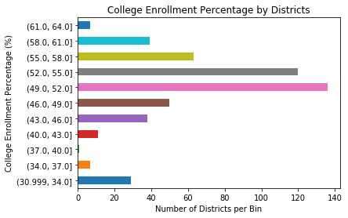

```python
binValues = np.arange(int(dfCollegeAll.lea_percent_enrolled.min()), int(dfCollegeAll.lea_percent_enrolled.max()), 3)
districtOut = pd.cut(dfCollegeAll.lea_percent_enrolled, bins = binValues, include_lowest = True)
count = districtOut.value_counts(sort=False)
ax = count.plot.barh(x = binValues, y = count).set(title = 'College Enrollment Percentage by Districts',
                                             xlabel = 'Number of Districts per Bin',
                                             ylabel = 'College Enrollment Percentage (%)')
```

This graph displays the postsecondary enrollment rate for public schools in NC. Due to the number of schoools, they were binned into groups seperated by 3%. We can see that the majority of schools within NC have a postsecondary enrollment rate around 50%. Further analysis will be necessary to understand why certain schools have an enrollment rate of greater than 60%. As well as why certain schools have an enrollment rate less than 40%.

END NEW MATERIAL

```
Text(0.5,1,'Distribution of Normalized Teacher Attributes')
```

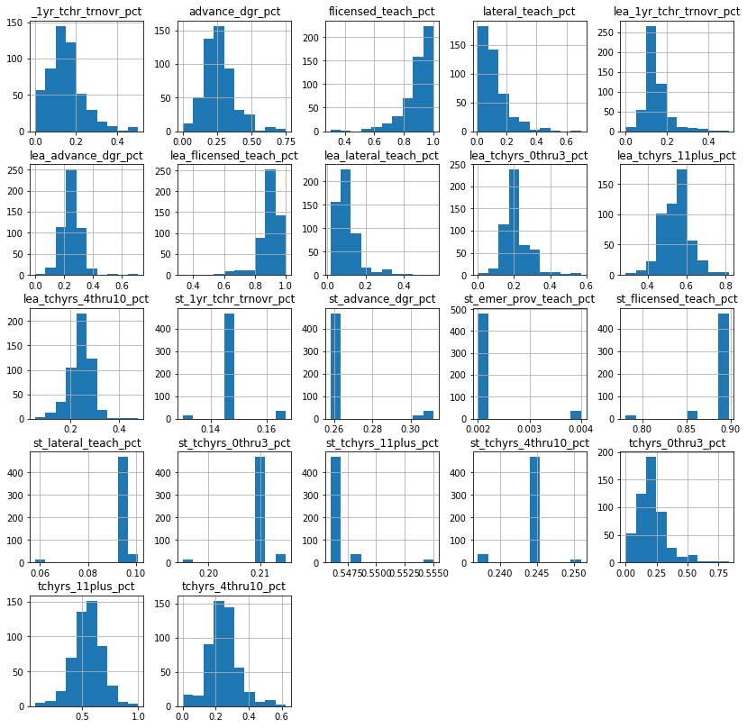

```python
ordinalM = [col for col in dfMergedSet if '_pct' in col]
ax42 = dfMergedSet.hist(column = ordinalM, figsize = (14,14))
plt.title('Distribution of Normalized Teacher Attributes')
```

Missing values removed from district calculations as these schools are Non-District schools and therefore do not have data on the district level

NEW MATERIAL

```
[Text(0,0,'By School'), Text(0,0,'By District')]
```

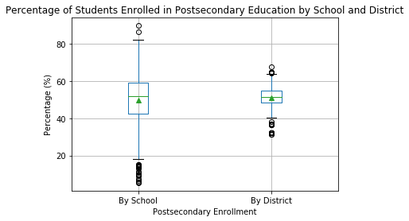

```python
ax = dfMergedSet.boxplot(column = ['sch_percent_enrolled', 'lea_percent_enrolled'], showmeans=True)
plt.title('Percentage of Students Enrolled in Postsecondary Education by School and District')
ax.set_ylabel('Percentage (%)')
ax.set_xlabel('Postsecondary Enrollment')
ax.xaxis.set_ticklabels(['By School', 'By District'])
```

As expected there is a large increase in variance in college enrollment rates at the individual school level compared to the district level. While this is the case, their medians and means are nearly identical.

```
[Text(0,0,'Graduate Degree'),
 Text(0,0,'Licensed'),
 Text(0,0,'0-3 Years Exp'),
 Text(0,0,'4-10 Years Exp'),
 Text(0,0,'11+ Years Exp'),
 Text(0,0,'1 Year Turnover')]
```

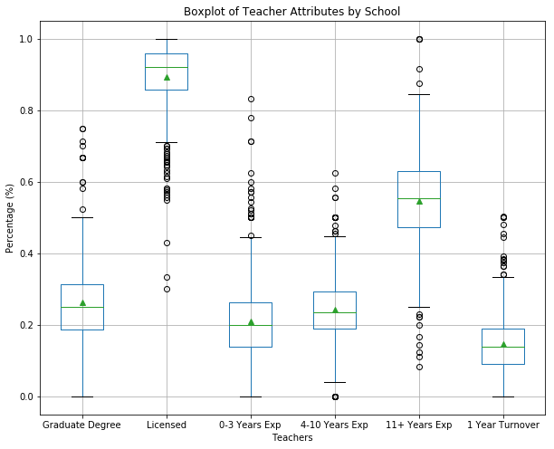

```python
ax = dfMergedSet.boxplot(column = ['advance_dgr_pct', 'flicensed_teach_pct', 'tchyrs_0thru3_pct', 'tchyrs_4thru10_pct', 'tchyrs_11plus_pct', '_1yr_tchr_trnovr_pct'], figsize = (10, 8), showmeans=True)
plt.title('Boxplot of Teacher Attributes by School')
ax.set_xlabel('Teachers')
ax.set_ylabel('Percentage (%)')
ax.xaxis.set_ticklabels(['Graduate Degree', 'Licensed', '0-3 Years Exp', '4-10 Years Exp', '11+ Years Exp', '1 Year Turnover'])
```

A notable trend here is that a majority of teachers have more than 11 years experience. The median of percent teachers with 11+ years of experience at a school (56%) is more than double that of teachers with 0-3 (20%) or 4-10 (23%) years experience. This tells us that the median school will be more than half staffed with teachers with over 11 years of experience.